# Data Mining Phase 2

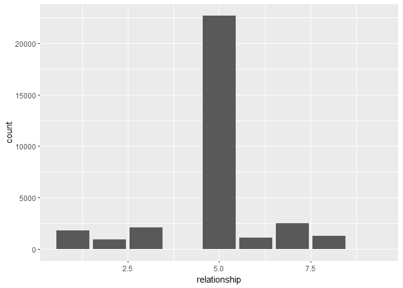

```r
# Bar plot of the relationship variable
ggplot(dataset, aes(x = relationship)) + geom_bar()
```

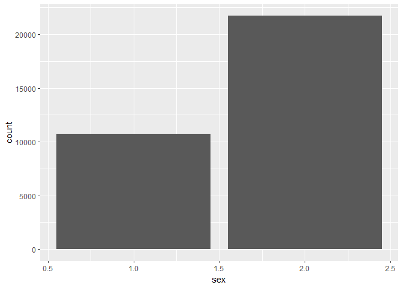

```r
# Bar plot of the sex variable
ggplot(dataset, aes(x = sex)) +geom_bar()
```

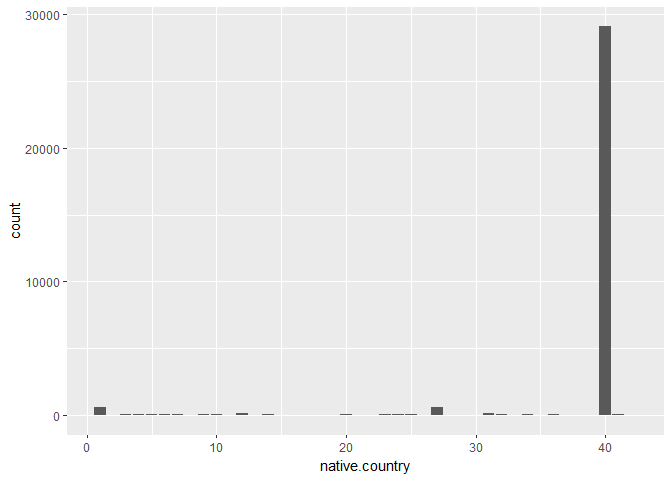

```r
# Bar plot of the native-country variable
ggplot(dataset, aes(x = native.country)) + geom_bar()
```

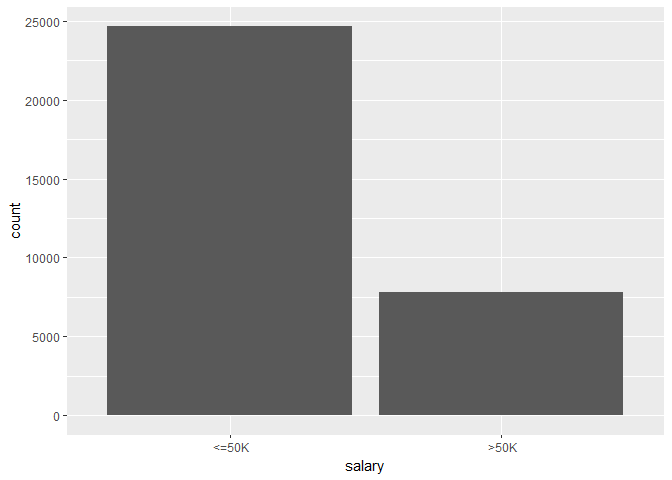

```r
# Bar plot of the salary variable
ggplot(dataset, aes(x = salary)) + geom_bar()
```

*Boxplots

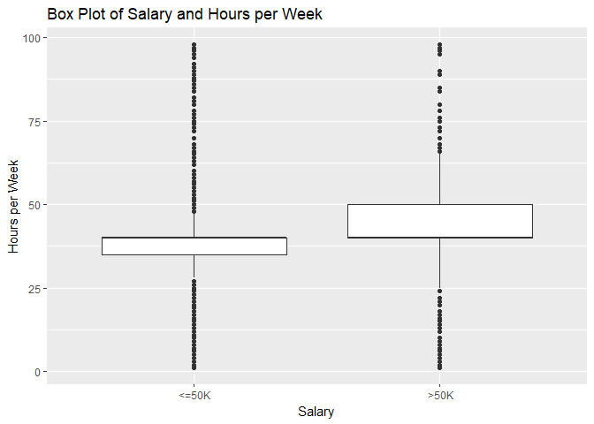

```r
ggplot(dataset, aes(x = salary, y = hours.per.week)) +
  geom_boxplot() +
  labs(title = "Box Plot of Salary and Hours per Week", x = "Salary", y = "Hours per Week")
```

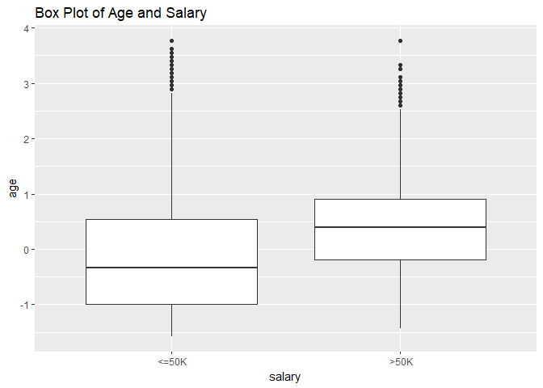

```r
ggplot(dataset, aes(x = salary, y = age)) +
  geom_boxplot() +
  labs(title = "Box Plot of Age and Salary", x = "salary", y = "age")
```

*Scatterplot

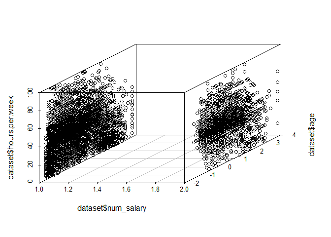

```r
scatterplot3d(dataset$num_salary,dataset$age, dataset$hours.per.week)
```

*Pie chart

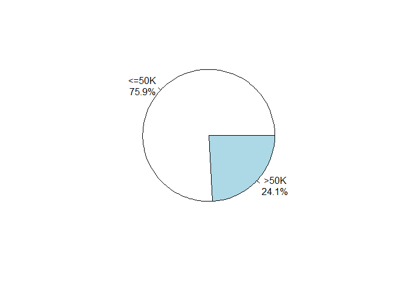

```r
tab <- dataset$salary %>% table()
precentages <- tab %>% prop.table() %>% round(3) * 100
txt <- paste0(names(tab), '\n', precentages, '%')
pie(tab, labels=txt)
```

##CLUSTERING

First, we install the needed packages and libraries.

```r
install.packages("dplyr",  repos = "https://cran.r-project.org")
install.packages("tidyverse",  repos = "https://cran.r-project.org")
```

```
## Error in install.packages : Updating loaded packages
```

```r
install.packages("e1071",  repos = "https://cran.r-project.org")
```

```
## Error in install.packages : Updating loaded packages
```

```r
install.packages("cluster",  repos = "https://cran.r-project.org")
```

```
## Error in install.packages : Updating loaded packages
```

```r
install.packages("factoextra",  repos = "https://cran.r-project.org")
```

```
## Error in install.packages : Updating loaded packages
```

```r
install.packages("fpc",  repos = "https://cran.r-project.org")
```

```
## Error in install.packages : Updating loaded packages
```

```r
library(dplyr)
library(tidyverse)
library(e1071)
library(cluster)
library(factoextra)
library(fpc)
```

Take a sample of the first 10,000 rows in the dataset.

```r
sampleDataset = dataset[1:10000,]
```

Preparing the data before clustering:

We will first start by deleting the class label, as clustering is an unsupervised learning.

```r
data_clustring <- subset(sampleDataset, select = -salary)
data_clustring <- subset(sampleDataset, select = -num_salary)
View(data_clustring)
```

Converting categorical attributes into numerical

```r
data_clustring$workclass <-  as.numeric(factor(data_clustring$workclass))
data_clustring$fnlwgt <-  as.numeric(factor(data_clustring$fnlwgt))
data_clustring$age <-  as.numeric(factor(data_clustring$age))
data_clustring$education.num <-  as.numeric(factor(data_clustring$education.num))
data_clustring$marital.status <-  as.numeric(factor(data_clustring$marital.status))
data_clustring$occupation <-  as.numeric(factor(data_clustring$occupation))
data_clustring$relationship <-  as.numeric(factor(data_clustring$relationship))
data_clustring$race <-  as.numeric(factor(data_clustring$race))
data_clustring$hours.per.week <-  as.numeric(factor(data_clustring$hours.per.week))
data_clustring$sex <-  as.numeric(factor(data_clustring$sex))
data_clustring$native.country <-  as.numeric(factor(data_clustring$native.country))
data_clustring <- scale(data_clustring[, sapply(data_clustring, is.numeric)])
```

#Data after preparing and converting categorical attributes into numeric values

```r
summary(data_clustring)
```

```
##       age            workclass          fnlwgt        education.num      marital.status      occupation
##  Min.   :-1.5780   Min.   :-2.643   Min.   :-1.7404   Min.   :-3.56366   Min.   :-1.7301   Min.   :-1.5493
##  1st Qu.:-0.7687   1st Qu.: 0.089   1st Qu.:-0.8473   1st Qu.:-0.42235   1st Qu.:-0.4054   1st Qu.:-0.8467
##  Median :-0.1065   Median : 0.089   Median :-0.0168   Median :-0.02968   Median :-0.4054   Median : 0.0901
##  Mean   : 0.0000   Mean   : 0.000   Mean   : 0.0000   Mean   : 0.00000   Mean   : 0.0000   Mean   : 0.0000
##  3rd Qu.: 0.6292   3rd Qu.: 0.089   3rd Qu.: 0.8521   3rd Qu.: 0.75564   3rd Qu.: 0.9193   3rd Qu.: 0.7927
##  Max.   : 3.5722   Max.   : 2.821   Max.   : 1.7830   Max.   : 2.32630   Max.   : 2.2440   Max.   : 1.7295
##   relationship         race              sex          hours.per.week     native.country
##  Min.   :-2.643   Min.   :-4.3336   Min.   :-1.4232   Min.   :-3.37489   Min.   :-4.5993
##  1st Qu.: 0.089   1st Qu.: 0.3911   1st Qu.:-1.4232   1st Qu.:-0.02547   1st Qu.: 0.2971
##  Median : 0.089   Median : 0.3911   Median : 0.7026   Median :-0.02547   Median : 0.2971
##  Mean   : 0.000   Mean   : 0.0000   Mean   : 0.0000   Mean   : 0.00000   Mean   : 0.0000
##  3rd Qu.: 0.089   3rd Qu.: 0.3911   3rd Qu.: 0.7026   3rd Qu.: 0.40394   3rd Qu.: 0.2971
##  Max.   : 2.821   Max.   : 0.3911   Max.   : 0.7026   Max.   : 3.58159   Max.   : 0.5548
```

```r
str(data_clustring)
```

```
##  num [1:10000, 1:11] 0.0406 0.8499 -0.0329 1.0707 -0.7687 ...
##  - attr(*, "dimnames")=List of 2
##   ..$ : chr [1:10000] "1" "2" "3" "4" ...
##   ..$ : chr [1:11] "age" "workclass" "fnlwgt" "education.num" ...
##  - attr(*, "scaled:center")= Named num [1:11] 22.45 4.87 4202.05 10.08 3.61 ...
##   ..- attr(*, "names")= chr [1:11] "age" "workclass" "fnlwgt" "education.num" ...
##  - attr(*, "scaled:scale")= Named num [1:11] 13.59 1.46 2413.84 2.55 1.51 ...
##   ..- attr(*, "names")= chr [1:11] "age" "workclass" "fnlwgt" "education.num" ...
```

```r
print(data_clustring)
```

```
##               age  workclass        fnlwgt education.num marital.status  occupation relationship       race
## 1      0.04063491  2.1381630 -1.305409e+00    1.14830495      0.9192678 -1.31513685    2.1381630  0.3910903
## 2      0.84994880  1.4551093 -1.262738e+00    1.14830495     -0.4054210 -0.61251890    1.4551093  0.3910903
## 3     -0.03293907  0.0890019  6.085504e-01   -0.42234879     -1.7301098 -0.14410694    0.0890019  0.3910903
## 4      1.07067076  0.0890019  8.069890e-01   -1.20767566     -0.4054210 -0.14410694    0.0890019 -1.9712792
## 5     -0.76867897  0.0890019  1.435447e+00    1.14830495     -0.4054210  0.79271699    0.0890019 -1.9712792
## 6     -0.10651306  0.0890019  1.174038e+00    1.54096838     -0.4054210 -0.61251890    0.0890019  0.3910903
## 7      0.77637481  0.0890019 -3.360008e-01   -1.99300252      0.2569234  0.32430502    0.0890019 -1.9712792
## 8      0.99709677  1.4551093  5.331520e-01   -0.42234879     -0.4054210 -0.61251890    1.4551093  0.3910903
## 9     -0.54795700  0.0890019 -1.518761e+00    1.54096838      0.9192678  0.79271699    0.0890019  0.3910903
## 10     0.26135688  0.0890019 -3.509147e-01    1.14830495     -0.4054210 -0.61251890    0.0890019  0.3910903
## 11    -0.10651306  0.0890019  1.147525e+00   -0.02968536     -0.4054210 -0.61251890    0.0890019 -1.9712792
## 12    -0.62153099  2.1381630 -5.725528e-01    1.14830495     -0.4054210  0.79271699    2.1381630 -3.1524639
## 13    -1.13654891  0.0890019 -7.883911e-01    1.14830495      0.9192678 -1.31513685    0.0890019  0.3910903
## 14    -0.47438301  0.0890019  4.639678e-01    0.75564151      0.9192678  1.26112895    0.0890019 -1.9712792
```

[output cut: 178 more lines]

It is a good idea to experiment with different values of k to determine the best value for our dataset. By using various methods, such as the silhouette coefficient or the gap statistic, to evaluate the quality of different clustering solutions and select the one that best represents the underlying structure of the data.

#Perform K-means clustering (for k = 2 clusters)

```r
kmeans_model <- kmeans(data_clustring,2 , nstart = 50)
kmeans_model
```

```
## K-means clustering with 2 clusters of sizes 1504, 8496
##
## Cluster means:
##           age  workclass       fnlwgt education.num marital.status occupation relationship        race
## 1  0.18739154 -1.9338180 -0.013814029    0.08675606     0.07592369 -0.5371494   -1.9338180 -0.11939516
## 2 -0.03317289  0.3423331  0.002445421   -0.01535795    -0.01344035  0.0950886    0.3423331  0.02113587
##           sex hours.per.week native.country
## 1 -0.16809451     -0.2443476     0.06271912
## 2  0.02975684      0.0432555    -0.01110282
##
## Clustering vector:
##    1    2    3    4    5    6    7    8    9   10   11   12   13   14   15   16   17   18   19   20   21   22
##    2    2    2    2    2    2    2    2    2    2    2    2    2    2    2    2    2    2    2    2    2    2
##   23   24   25   26   27   28   29   30   31   32   33   34   35   36   37   38   39   40   41   42   43   44
##    1    2    2    1    2    1    2    2    1    2    2    1    2    2    2    2    2    2    2    2    2    2
```

[output cut: 98 more lines]

# Extract the cluster assignments

```r
clusters <- kmeans_model$cluster
```

# Visualize the clusters

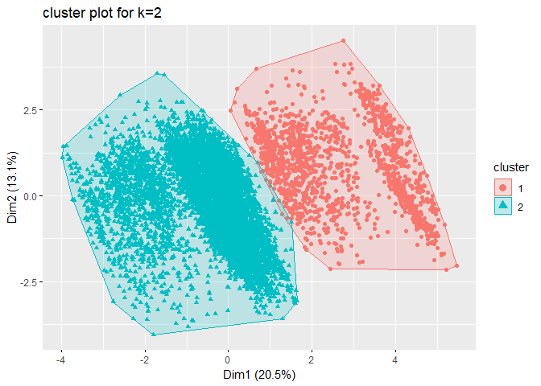

```r
fviz_cluster(list(data = data_clustring, cluster = clusters), geom = "point", main= "cluster plot for k=2")
```

# Calculating the avg silhouette

```
##   cluster size ave.sil.width
## 1       1 1504          0.16
## 2       2 8496          0.23
```

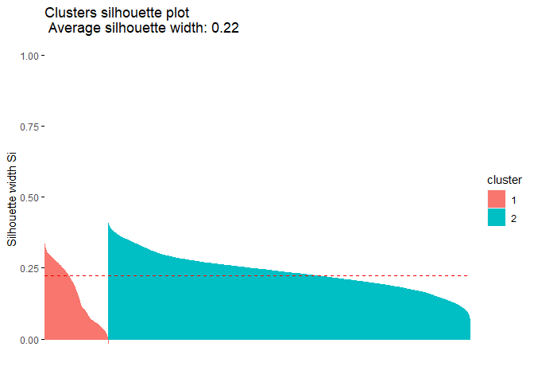

```r
avg_sil=silhouette (kmeans_model$cluster, dist(data_clustring))
fviz_silhouette(avg_sil)
```

The WCSS is a measure of the compactness of the clusters, and it represents the total distance of all data points within their respective clusters. A lower WCSS indicates that the clusters are more compact and well-separated, while a higher WCSS suggests that the clusters are more spread out and less distinct.

# Total within-cluster sum of square

```r
kmeans_model$tot.withinss
```

```
## [1] 95964.09
```

# Calculate BCubed precision and recall

# First we set the ground truth

```r
ground_truth <- c(sampleDataset$salary)
```

# Setting the functions for calculating the BCubed precision and recall

```r
BCubed_Precision <- function(clusters, ground_truth) {
  n <- length(clusters)
  precision <- 0
  for (i in 1:n) {
    same_cluster <- clusters == clusters[i]
    same_ground_truth <- ground_truth == ground_truth[i]
    precision <- precision + sum(same_cluster & same_ground_truth) / sum(same_cluster)
  }
  precision <- precision / n
  return(precision)
}

BCubed_Recall <- function(clusters, ground_truth) {
  n <- length(clusters)
  recall <- 0
  for (i in 1:n) {
    same_cluster <- clusters == clusters[i]
    same_ground_truth <- ground_truth == ground_truth[i]
    recall <- recall + sum(same_cluster & same_ground_truth) / sum(same_ground_truth)
  }
  recall <- recall / n
  return(recall)
}
```

# Calculate BCubed precision and recall using the cluster assignments and ground truth

```r
precision <- BCubed_Precision(clusters, ground_truth)
recall <- BCubed_Recall(clusters, ground_truth)
```

# View the calculated precision and recall

```r
print(precision)
```

```
## [1] 0.6377602
```

```r
print(recall)
```

```
## [1] 0.7444775
```

# Perform K-means clustering (for k = 3 clusters)

```r
kmeans_model <- kmeans(data_clustring,3 , nstart = 50)
kmeans_model
```

```
## K-means clustering with 3 clusters of sizes 3437, 5089, 1474
##
## Cluster means:
##          age  workclass      fnlwgt education.num marital.status  occupation relationship       race
## 1 -0.6116840  0.2352712  0.11915858   -0.16769450     0.88188204  0.08423878    0.2352712 -0.1952063
## 2  0.3550556  0.4050938 -0.07556317    0.08651648    -0.61926102  0.10804762    0.4050938  0.1671085
## 3  0.2004612 -1.9471840 -0.01696544    0.09232269     0.08167623 -0.56945932   -1.9471840 -0.1217715
##          sex hours.per.week native.country
## 1 -0.4323738     -0.4043853    -0.08445041
## 2  0.3424943      0.3478605     0.03858044
## 3 -0.1742775     -0.2580664     0.06371790
##
## Clustering vector:
##    1    2    3    4    5    6    7    8    9   10   11   12   13   14   15   16   17   18   19   20   21   22
##    2    2    2    2    1    2    1    2    1    2    2    2    1    1    2    1    1    1    2    2    2    1
```

[output cut: 100 more lines]

# Extract the cluster assignments

```r
clusters <- kmeans_model$cluster
```

# Visualize the clusters

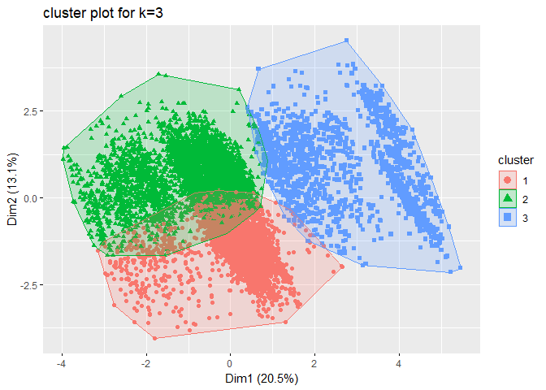

```r
fviz_cluster(list(data = data_clustring, cluster = clusters), geom = "point", main= "cluster plot for k=3")
```

# calculating the avg silhouette

```
##   cluster size ave.sil.width
## 1       1 3437          0.10
## 2       2 5089          0.16
## 3       3 1474          0.13
```

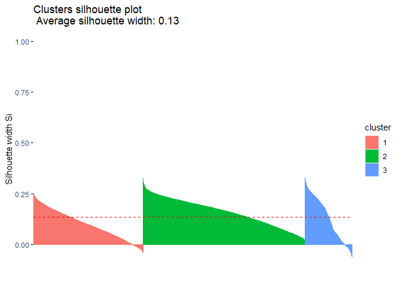

```r
avg_sil=silhouette (kmeans_model$cluster, dist(data_clustring))
fviz_silhouette(avg_sil)
```

# Total within-cluster sum of square

```r
kmeans_model$tot.withinss
```

```
## [1] 86459.06
```

# Calculate BCubed precision and recall

# First we set the ground truth

```r
ground_truth <- c(sampleDataset$salary)
```

# Setting the functions for calculating the BCubed precision and recall

```r
BCubed_Precision <- function(clusters, ground_truth) {
  n <- length(clusters)
  precision <- 0
  for (i in 1:n) {
    same_cluster <- clusters == clusters[i]
    same_ground_truth <- ground_truth == ground_truth[i]
    precision <- precision + sum(same_cluster & same_ground_truth) / sum(same_cluster)
  }
  precision <- precision / n
  return(precision)
}

BCubed_Recall <- function(clusters, ground_truth) {
  n <- length(clusters)
  recall <- 0
  for (i in 1:n) {
    same_cluster <- clusters == clusters[i]
    same_ground_truth <- ground_truth == ground_truth[i]
    recall <- recall + sum(same_cluster & same_ground_truth) / sum(same_ground_truth)
  }
  recall <- recall / n
  return(recall)
}
```

# Calculate BCubed precision and recall using the cluster assignments and ground truth

```r
precision <- BCubed_Precision(clusters, ground_truth)
recall <- BCubed_Recall(clusters, ground_truth)
```

# View the calculated precision and recall

```r
print(precision)
```

```
## [1] 0.6753127
```

```r
print(recall)
```

```
## [1] 0.4416032
```

# Perform K-means clustering (for k = 4 clusters)

```r
kmeans_model <- kmeans(data_clustring,4 , nstart = 50)
kmeans_model
```

```
## K-means clustering with 4 clusters of sizes 4800, 3204, 581, 1415
##
## Cluster means:
##           age  workclass      fnlwgt education.num marital.status  occupation relationship       race
## 1  0.34607427  0.4026374 -0.07365831    0.06103626    -0.63517172  0.10117503    0.4026374  0.1809378
## 2 -0.62858068  0.2373806  0.10410580   -0.13275338     0.90913830  0.07547944    0.2373806 -0.1320374
## 3  0.09837973  0.1113393  0.08789215    0.02303022     0.02436185  0.15499949    0.1113393 -0.5156367
## 4  0.20894516 -1.9490566 -0.02195081    0.08408991     0.08607130 -0.57776042   -1.9490566 -0.1030874
##           sex hours.per.week native.country
## 1  0.33675816     0.34392943      0.2442916
## 2 -0.43529154    -0.40387585      0.2070369
## 3  0.05861614     0.02848098     -3.7099494
## 4 -0.18079227    -0.26388020      0.2258197
##
## Clustering vector:
```

[output cut: 102 more lines]

# Extract the cluster assignments

```r
clusters <- kmeans_model$cluster
```